# xwMOOC 자연어 처리 - 텍스트

케인즈 vs 하이에크 - 감성, 핵심어, 연관단어

xwMOOC

Tidyverse Korea

2019-01-29

# 1 케인즈 vs 하이에크 저서 데이터 [^1]

`pdf_text` 함수로 `.pdf` 파일을 R에서 처리 가능한 문자열을 뽑아내서 객체에 담아낸다.

```r
library(pdftools)
library(tidyverse)
library(tidytext)

keynes_pdf <- pdf_text("data/generaltheory.pdf")
hayek_pdf <- pdf_text("data/The-Road-to-Serfdom-F.A.-Hayek.pdf")

keynes_df <- keynes_pdf %>%
  tbl_df() %>%
  mutate(book = "케인즈") %>%
  unnest_tokens(word, value)

hayek_df <- hayek_pdf %>%
  tbl_df() %>%
  mutate(book = "하이에크") %>%
  unnest_tokens(word, value)

data(stop_words)

book_df <- bind_rows(keynes_df, hayek_df) %>%
  mutate(word = str_to_lower(word)) %>%
  anti_join(stop_words)
```

# 2 감성분석

## 2.1 감성사전

일반이론과 노예의 길에 사용된 긍정어와 부정어를 살펴본다. `negative`, `positive`로 감성사전이 구성된 `bing`을 활용하여 가장 많이 언급된 긍부정어를 시각화한다.

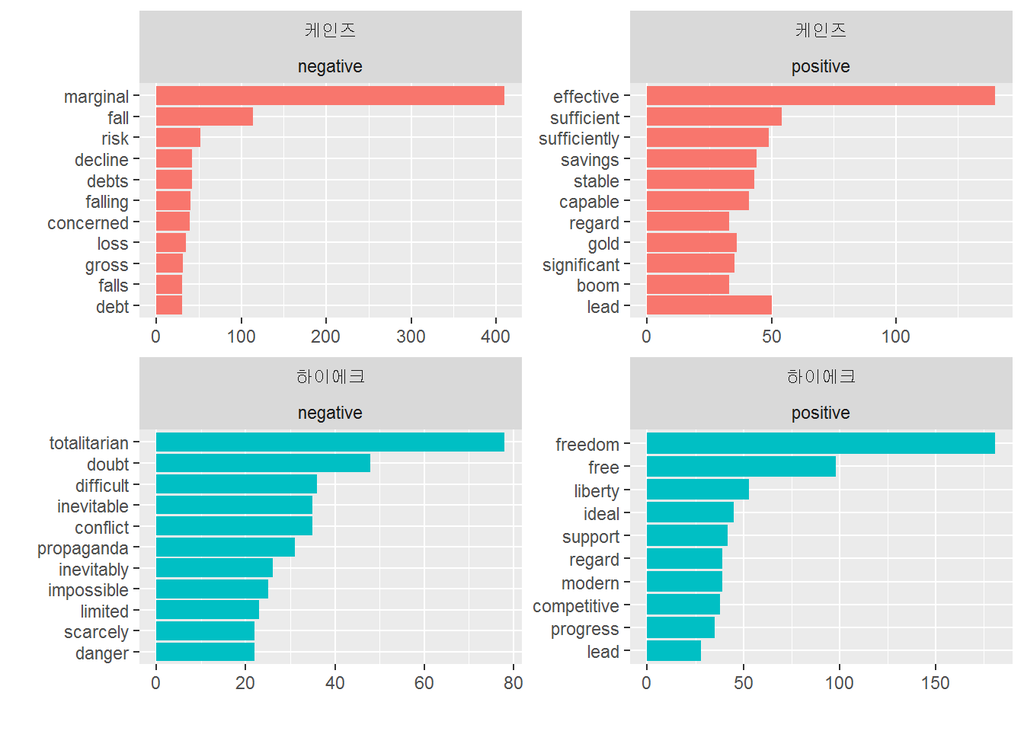

```r
# 2. 감성 분석 -------------------
## 2.1. 긍정/부정 단어 -----------
senti_word_counts <- book_df %>%
    inner_join(get_sentiments("bing")) %>%
    count(book, word, sentiment)

top_senti_word_counts <- senti_word_counts %>%
    group_by(book, sentiment) %>%
    top_n(10, n) %>%
    ungroup()

top_senti_word_counts %>%
  group_by(book) %>%
  ggplot(aes(x=fct_reorder2(word, sentiment, -n), y=n, fill = book)) +
    geom_col(show.legend = FALSE) +
    facet_wrap(book~sentiment, scales = "free") +
    coord_flip() +
    labs(x="", y="")
```

`nrc` 감성사전을 활용하여 각 감정을 표현하는데 많이 사용된 단어를 상위 10개씩 각 책으로부터 뽑아보자.

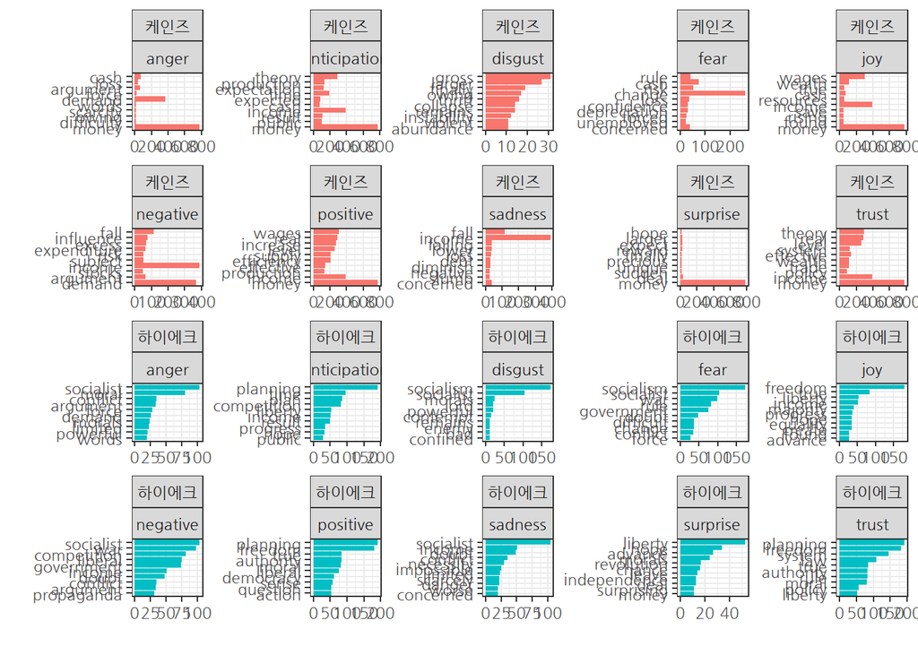

```r
library(extrafont)
loadfonts()

book_df %>%
    inner_join(get_sentiments("nrc")) %>%
    count(book, word, sentiment) %>%
    group_by(book, sentiment) %>%
    top_n(10, n) %>%
    # ungroup() %>%
    ggplot(aes(x=fct_reorder2(word, book, -n), y=n, fill = book)) +
      geom_col(show.legend = FALSE) +
      facet_wrap(book ~ sentiment, scales = "free") +
      coord_flip() +
      theme_bw(base_family = "NanumGothic") +
      theme(legend.position = "none") +
      labs(x="", y="", fill="책제목")
```

## 2.2 감성 비교

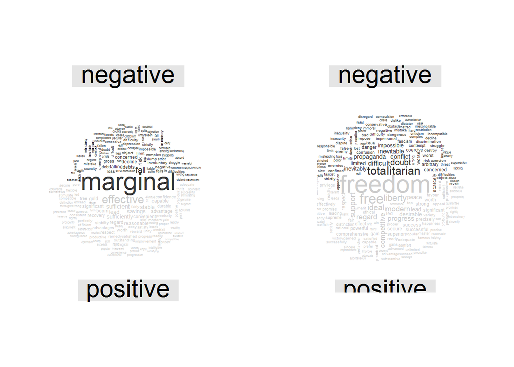

```r
library(reshape2)
library(wordcloud)

par(mfrow=c(1,2))

keynes_senti_df <- senti_word_counts %>%
  filter(book == "케인즈") %>%
  select(-book)

keynes_senti_df %>%
  acast(word ~ sentiment, value.var = "n", fill = 0) %>%
  comparison.cloud(title.size = 2,  scale = c(2,  0.2),
                   random.order = FALSE, colors = c("gray20", "gray80"),
                   max.words = 200)

hayek_senti_df <- senti_word_counts %>%
  filter(book != "케인즈") %>%
  select(-book)

hayek_senti_df %>%
  acast(word ~ sentiment, value.var = "n", fill = 0) %>%
  comparison.cloud(title.size = 2,  scale = c(2,  0.2),
                   random.order = FALSE, colors = c("gray20", "gray80"),
                   max.words = 200)
```

# 3 저서 핵심용어 - TF-IDF

TF-IDF(Term Frequency - Inverse Document Frequency)는 텍스트 마이닝에서 이용하는 가중치로, 여러 문서로 이루어진 문서군이 있을 때 어떤 단어가 특정 문서 내에서 얼마나 중요한 것인지를 나타내는 통계적 수치로 문서의 핵심어를 추출하는 용도로 사용할 수 있다. 일반이론과 노예의 길 문서가 두권의 책이라 케이즈와 하이에크를 옹호하는 책 혹은 문서를 더 확충할 경우 핵심용어를 식벽하는데 큰 도움이 될 수 있다.

```r
book_word_df <- book_df %>%
  count(book, word, sort=TRUE)

total_word_df <- book_word_df %>%
  group_by(book) %>%
  summarize(total = sum(n))

book_total_word_df <- left_join(book_word_df, total_word_df)

book_total_word_df
```

```
# A tibble: 13,544 x 4
   book   word           n total
   <chr>  <chr>      <int> <int>
 1 케인즈 money        779 51842
 2 케인즈 rate         776 51842
 3 케인즈 employment   661 51842
 4 케인즈 investment   583 51842
 5 케인즈 capital      525 51842
 6 케인즈 marginal     410 51842
 7 케인즈 income       390 51842
 8 케인즈 cost         371 51842
 9 케인즈 demand       370 51842
10 케인즈 output       362 51842
# ... with 13,534 more rows
```

```r
book_total_word_df <- book_total_word_df %>%
  bind_tf_idf(word, book, n)

book_total_word_df %>%
  select(-total) %>%
  arrange(desc(tf_idf))
```

```
# A tibble: 13,544 x 6
   book     word            n      tf   idf   tf_idf
   <chr>    <chr>       <int>   <dbl> <dbl>    <dbl>
 1 케인즈   saving        184 0.00355 0.693 0.00246
 2 하이에크 serfdom       111 0.00353 0.693 0.00244
 3 케인즈   liquidity     132 0.00255 0.693 0.00176
 4 하이에크 socialists     64 0.00203 0.693 0.00141
 5 하이에크 democracy      61 0.00194 0.693 0.00134
 6 하이에크 ideals         57 0.00181 0.693 0.00126
 7 케인즈   prospective    85 0.00164 0.693 0.00114
 8 케인즈   equilibrium    81 0.00156 0.693 0.00108
 9 하이에크 tion           49 0.00156 0.693 0.00108
10 케인즈   assets         72 0.00139 0.693 0.000963
# ... with 13,534 more rows
```

케이즈와 하이에크의 두 저서만을 대상으로 TF-IDF 수치가 높은 단어를 상위 15개 추출하여 막대그래프로 시각화한다.

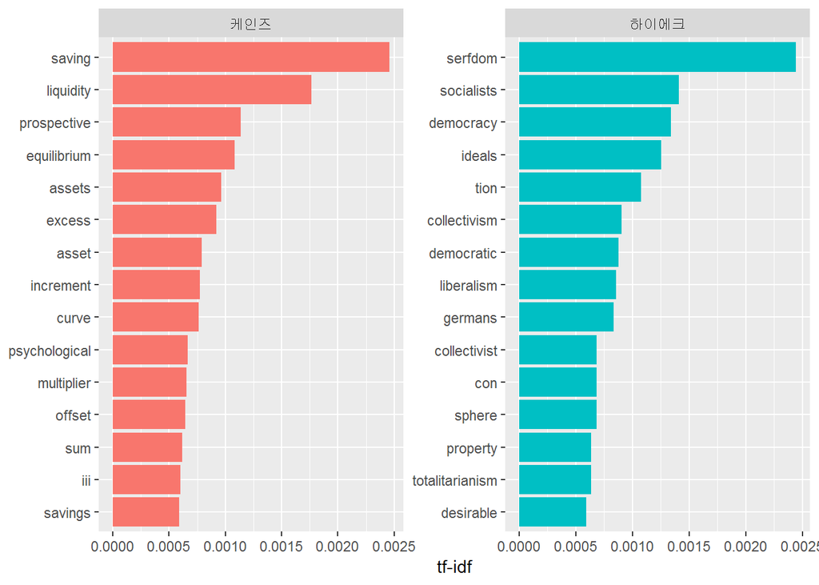

```r
book_total_word_df %>%
  arrange(desc(tf_idf)) %>%
  mutate(word = factor(word, levels = rev(unique(word)))) %>%
  group_by(book) %>%
  top_n(15) %>%
  ungroup %>%
    ggplot(aes(word, tf_idf, fill = book)) +
    geom_col(show.legend = FALSE) +
    labs(x = NULL, y = "tf-idf") +
    facet_wrap(~book, ncol = 2, scales = "free") +
    coord_flip()
```

# 4 단어 연관성 - `ngram`

단어 연관성을 살펴보기 위해서 `n-gram`기법을 사용한다. 단어를 2개씩 나눠서 살펴본다.

```r
keynes_bigram_df <- keynes_pdf %>%
  tbl_df() %>%
  mutate(book = "케인즈") %>%
  unnest_tokens(bigram, value, token="ngrams", n=2)

hayek_bingram_df <- hayek_pdf %>%
  tbl_df() %>%
  mutate(book = "하이에크") %>%
  unnest_tokens(bigram, value, token="ngrams", n=2)

bigram_book_df <- bind_rows(keynes_bigram_df, hayek_bingram_df) %>%
  mutate(bigram = str_to_lower(bigram))

bigram_book_df %>%
  count(book, bigram, sort=TRUE)
```

```
# A tibble: 97,083 x 3
   book     bigram          n
   <chr>    <chr>       <int>
 1 케인즈   of the       1515
 2 케인즈   in the       1260
 3 하이에크 of the       1137
 4 케인즈   to the        716
 5 케인즈   rate of       709
 6 케인즈   of interest   652
 7 케인즈   it is         563
 8 케인즈   that the      456
 9 케인즈   the rate      454
10 하이에크 in the        438
# ... with 97,073 more rows
```

불용어가 많아서 `stop_words`처럼 다음과 같이 `bi-gram` 불용어처리를 한다. 먼저 `bigram`을 두 단어로 쪼갠 후에 불용어가 들어간 단어를 추려낸다. 그리고 나서 다시 `unite()` 함수로 `bigram` 형태로 다시 되돌린다.

```r
bigram_book_sep_df <- bigram_book_df %>%
  separate(bigram, c("word1", "word2"), sep = " ")

bigram_book_no_stopword_df <- bigram_book_sep_df %>%
  filter(!word1 %in% stop_words$word) %>%
  filter(!word2 %in% stop_words$word)

bigram_book_clean_df <- bigram_book_no_stopword_df %>%
  unite(bigram, word1, word2, sep = " ")

bigram_book_clean_df
```

```
# A tibble: 25,085 x 2
   book   bigram
   <chr>  <chr>
 1 케인즈 john maynard
 2 케인즈 maynard keynes
 3 케인즈 money john
 4 케인즈 john maynard
 5 케인즈 maynard keynes
 6 케인즈 keynes table
 7 케인즈 contents preface
 8 케인즈 preface preface
 9 케인즈 german edition
10 케인즈 edition preface
# ... with 25,075 more rows
```

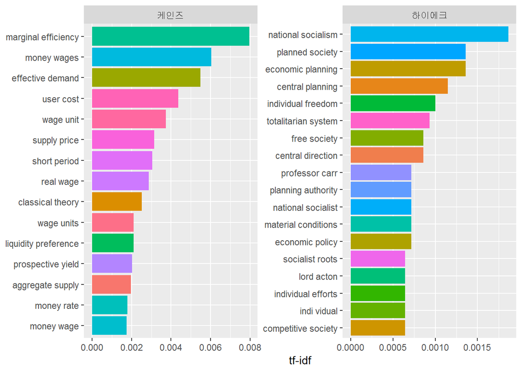

```r
bigram_book_clean_df %>%
  count(book, bigram) %>%
  bind_tf_idf(bigram, book, n) %>%
  arrange(desc(tf_idf)) %>%
  group_by(book) %>%
  top_n(15, wt=tf_idf) %>%
  ggplot(aes(x=fct_reorder(bigram, tf_idf), y=tf_idf, fill=bigram)) +
    geom_col(show.legend = FALSE) +
    facet_wrap(~ book, ncol = 2, scales = "free") +
    coord_flip() +
    labs(x = NULL, y = "tf-idf")
```

# 5 단어 연관성 - 네트워크

`bigram`으로 자료구조를 갖추게 되면 자연스럽게 `from`, `to` 형태 네트워크 자료구조와 동일하게 되어 `igraph` 팩키지를 통해 데이터프레임을 네트워크 자료형으로 변환시키고 이를 `ggraph` 팩키지로 시각화하는 것이 가능하다.

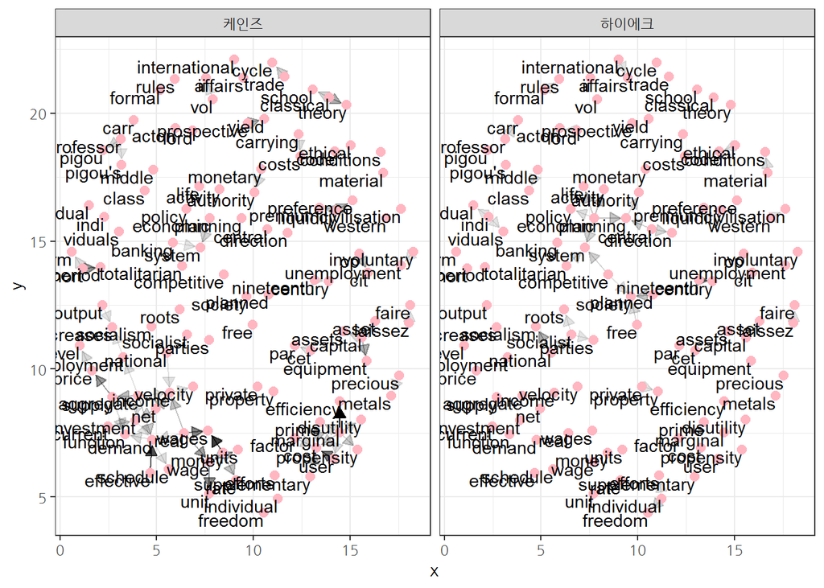

```r
library(igraph)
library(ggraph)
library(extrafont)
loadfonts()

bigram_graph <- bigram_book_no_stopword_df %>%
  count(book, word1, word2, sort=TRUE) %>%
  mutate(n = ifelse(book=="하이에크", n*2, n)) %>%
  filter(n > 15) %>%
  select(word1, word2, n, book) %>%
  graph_from_data_frame()

a <- grid::arrow(type = "closed", length = unit(.10, "inches"))

ggraph(bigram_graph, layout = "fr") +
  geom_edge_link(aes(edge_alpha = n), show.legend = FALSE,
                 arrow = a, end_cap = circle(.05, 'inches')) +
  geom_node_point(color = "lightpink", size = 2.5) +
  geom_node_text(aes(label = name), vjust = 1, hjust = 1) +
  theme_bw(base_family = "NanumGothic") +
  facet_wrap(~book)
```

[^1]: [Julia Silge and David Robinson (2018-12-21), “Text Mining with R - A Tidy Approach”](https://www.tidytextmining.com/)